# Chapter 3

```r
alc <- read.csv("./data/alc.csv")
str(alc)
```

```
## 'data.frame':    370 obs. of  35 variables:
##  $ school    : chr  "GP" "GP" "GP" "GP" ...
##  $ sex       : chr  "F" "F" "F" "F" ...
##  $ age       : int  15 15 15 15 15 15 15 15 15 15 ...
##  $ address   : chr  "R" "R" "R" "R" ...
##  $ famsize   : chr  "GT3" "GT3" "GT3" "GT3" ...
##  $ Pstatus   : chr  "T" "T" "T" "T" ...
##  $ Medu      : int  1 1 2 2 3 3 3 2 3 3 ...
##  $ Fedu      : int  1 1 2 4 3 4 4 2 1 3 ...
##  $ Mjob      : chr  "at_home" "other" "at_home" "services" ...
##  $ Fjob      : chr  "other" "other" "other" "health" ...
##  $ reason    : chr  "home" "reputation" "reputation" "course" ...
##  $ guardian  : chr  "mother" "mother" "mother" "mother" ...
##  $ traveltime: int  2 1 1 1 2 1 2 2 2 1 ...
##  $ studytime : int  4 2 1 3 3 3 3 2 4 4 ...
```

[output cut: 21 more lines]

Above we have printed some information of the data to be used in this week’s assignment, including variable names as well as data types of the variables. In total we have 370 observations and 35 variables. The data are student level results from a questionnaire in two Portuguese schools (secondary education) and the variables measure student achievement as well as demographic and social features. Based on this data, we shall study the relationship between alcohol consumption and some of the variables.

Of other variables than those related to alcohol consumption, we shall focus our attention on `higher`, `romantic`, `famrel` and `G3` (final grade). The working hypothesis is that the variables measuring social aspects (`romantic` and `famrel`) could be negatively correlated with alcohol consumption, whereas the variables related to ambitions and achievement (`higher` and `G3`) could as well be negatively associated with alcohol consumption, since excessive alcohol could make it more difficult to succeed in school.

For the analysis we need to encode `romantic` and `higher` (both take character values `yes` or `no`) to a binary variables taking values 1 and zero.

```r
alc$romantic_binary <- ifelse(alc$romantic == "yes", 1, 0)
alc$higher_binary <- ifelse(alc$higher == "yes", 1, 0)
```

Below we see the marginal distributions of the four explanatory variables for both `high_use = TRUE` and `high_use = FALSE`. Variable `high_use` takes values `TRUE` if the weekly alcohol consumption exceeds a certain threshold. For 30% of the students in the sample `high_use = TRUE`.

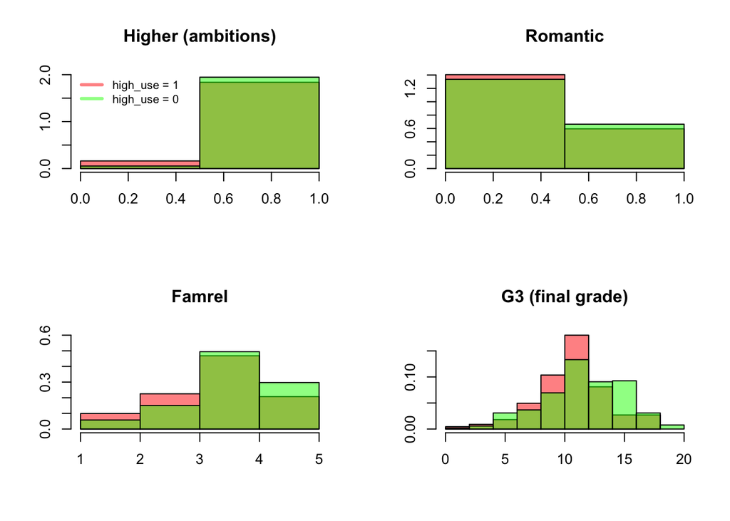

The conditional marginal distributions of the variables provide preliminary support for all of our hypotheses. First, `higher` is a binary variable taking zero values only if the student is not thinking about pursuing higher education and thus reflects the educational ambitions. As suspected, among those with lower educational ambitions, high alcohol consumption is much more common. The difference might not look huge in the plot since for only 4% of the students `higher = 0`, but among those (16) students high alcohol consumption was approximately twice as probable as in the rest of the data! (see table below)

[output not shown]

As for the next variable, whether student is in a romantic relationship does not seem to have much effect on one’s alcohol consumption. However, `high_use = TRUE` seems to be slightly more common for `romantic = “no”`, as hypothesized. Good family relations (higher values of `famrel`) on the other hand seem to be clearly associated with less alcohol consumption, also as hypothesized. Finally, perhaps the most clear negative association (by visual inspection at least) is between high alcohol consumption and final grade, or educational success, which makes perfect sense, and is also as we suspected.

Next, we shall estimate a logistic regression model using the four just discussed variables as explanatory variables and `high_use` as the dependent variable. Below we have printed out the summary of our results.

```r
# Logistic regression model
model <- glm(high_use ~ higher_binary + romantic_binary + famrel + G3,
             data = alc, family = binomial(link = "logit"))

# A summary of the estimated model
summary(model)
```

```
##
## Call:
## glm(formula = high_use ~ higher_binary + romantic_binary + famrel +
##     G3, family = binomial(link = "logit"), data = alc)
##
## Deviance Residuals:
##     Min       1Q   Median       3Q      Max
## -1.4342  -0.8506  -0.7251   1.3382   1.9521
##
## Coefficients:
##                 Estimate Std. Error z value Pr(>|z|)
## (Intercept)      2.06805    0.77766   2.659  0.00783 **
## higher_binary   -0.90841    0.55444  -1.638  0.10133
## romantic_binary -0.33272    0.25738  -1.293  0.19611
## famrel          -0.28414    0.12473  -2.278  0.02272 *
## G3              -0.07423    0.03716  -1.997  0.04578 *
## ---
## Signif. codes:  0 '***' 0.001 '**' 0.01 '*' 0.05 '.' 0.1 ' ' 1
##
## (Dispersion parameter for binomial family taken to be 1)
##
##     Null deviance: 452.04  on 369  degrees of freedom
## Residual deviance: 436.57  on 365  degrees of freedom
## AIC: 446.57
##
## Number of Fisher Scoring iterations: 4
```

```r
# Odds ratios
odds_ratios <- exp(model$coefficients)

# Confidence intervals
ci <- confint(model)
# Printing out both odds ratios and their confidence intervals
print(cbind(odds_ratios, exp(ci)))
```

```
##                 odds_ratios     2.5 %     97.5 %
## (Intercept)       7.9093629 1.7560948 37.6713039
## higher_binary     0.4031642 0.1315342  1.1948265
## romantic_binary   0.7169700 0.4283564  1.1778900
## famrel            0.7526588 0.5885479  0.9614471
## G3                0.9284590 0.8625985  0.9983319
```

On the other hand, the coefficients on `famrel` and `G3` were found to be statistically significant on a 95% level, albeit small-ish in absolute value. Based on these findings, we could say the data and the model to give some support to our hypothesis of both healthy social relations and educational ambitions to be negatively associated with high alcohol consumption.

```
##         prediction
## high_use   0   1
##        0 249  10
##        1 105   6
```

Clearly, the model inaccurately classifies almost all of the students as `high_use = 0`. This is no surprise, since for 70% of the students this is indeed the case, thus by classifying every student like this, one would already obtain a respectable (not really) accuracy rate of 70%.

So does our model perform any better than such a simple guessing strategy? Unfortunately it turns out not to be the case… The accuracy rate of our model is only 68.92% (31.08% training error) against the 70% (30% training error) of the simple guessing strategy.

To conclude, the predictive performance of our model is poor, reflecting the weakness of our obtained results. However, the data and the model do give some support to our hypothesis of both healthy social relations and educational ambitions to be negatively associated with high alcohol consumption.